# Clustering in R Quick Reference

Mark Niemann-Ross

2021-03-10

# About

## About This Document

This document provides brief explanations of the clustering functions available in Base R and the cluster package.

## Related Material

[The cluster package](https://cran.r-project.org/web/packages/cluster/index.html) is recommended for advanced operations. The cluster package is based on [Finding Groups in Data](https://onlinelibrary.wiley.com/doi/book/10.1002/9780470316801)

An exhaustive discussion of clustering can be found at [Machine Learning and AI foundations:clustering and association](https://linkedin-learning.pxf.io/lilclustering)

This Quick Reference is supplemental to courses on [LinkedIn Learning](https://www.linkedin.com/learning/r-for-data-science-lunchbreak-lessons/). A quick reference to [matrix math functions in R is here](http://niemannross.com/link/rmatrixqref). A quick reference to [plotting functions in R is here](http://niemannross.com/link/rplotqref). An index to all R functions covered at LinkedIn Learning is found [here](http://niemannross.com/link/rindex). The latest version of this quick reference is found [here](http://niemannross.com/link/rclusterqref). The source to this document is found on [github/mnr](https://github.com/mnr/R-for-Data-Science-Lunchbreak-Lessons). This document is available as Free Software under the terms of the [Free Software Foundation’s](http://www.gnu.org/) [GNU General Public License](https://www.r-project.org/COPYING).

## About Mark Niemann-Ross

[Mark](https://niemannross.com/) is an author for LinkedIn Learning and writes Science Fiction.

# Partitioning methods

Divide dataset into k clusters. (k is defined by researcher)

## *kmeans* : Partitioning around centroids

```r
# kmeans clusters data together, based on average distance from a centroid
# kmeans iterates through possible solutions to identify the best result

kmeans(quakes, 3)
```

```
## K-means clustering with 3 clusters of sizes 224, 389, 387
##
## Cluster means:
##         lat     long     depth      mag stations
## 1 -20.15759 179.2072 268.58482 4.523214 30.47768
## 2 -20.87082 178.5534  88.67866 4.752185 35.96915
## 3 -20.69432 180.5229 559.97933 4.544186 32.55556
##
## Clustering vector:
##    [1] 3 3 2 3 3 1 2 1 1 3 3 1 3 3 2 1 2 3 3 3 3 1 3 2 3 3 2 3 3 1 3 2 1 1 2 3 1
##   [38] 3 3 1 1 2 3 2 1 2 1 2 3 2 3 1 2 3 3 3 3 3 3 3 3 1 3 2 3 1 3 3 3 2 2 1 2 3
##   [75] 3 3 1 1 1 1 2 1 3 1 3 2 2 3 2 2 2 1 3 1 1 1 1 1 2 3 2 3 3 2 3 1 2 2 2 2 1
##  [112] 1 3 3 3 3 2 2 2 1 2 2 3 3 1 2 3 3 2 1 1 3 2 3 3 2 2 1 2 1 3 3 1 1 3 1 2 2
##  [149] 3 3 2 2 1 2 2 3 2 3 2 2 3 3 1 2 2 2 1 1 3 1 3 3 3 2 1 1 3 1 3 1 3 2 2 1 3
##  [186] 2 1 3 3 1 1 1 3 3 3 3 1 2 3 3 1 3 1 1 3 1 3 3 1 3 1 1 1 2 3 3 1 3 1 1 2 2
```

[output cut: 31 more lines]

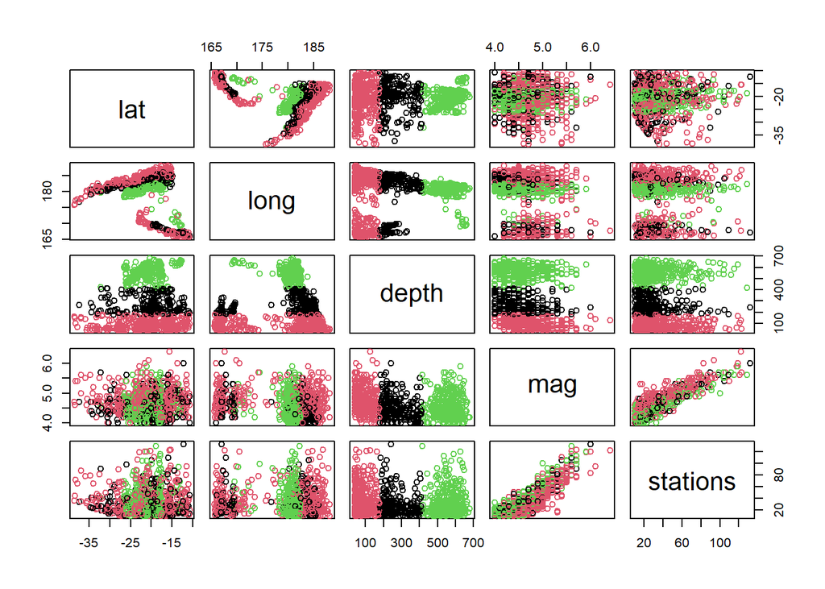

```r
# lots of information in the print from kmeans
# cluster sizes
# cl$centers - cluster means - shows the centroid for each cluster
# cl$cluster - clustering vector - shows which data points belong to which cluster
# cl$withinss - within cluster sum of squares - small SofS = more compact cluster


cl <- kmeans(quakes, 3)
plot(quakes, col = cl$cluster)
```

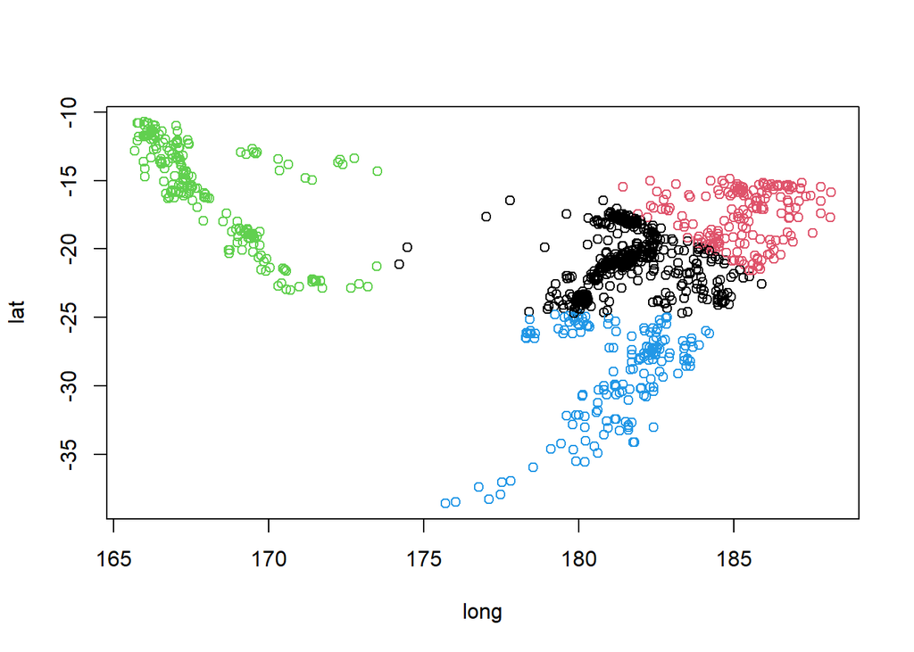

```r
# what are we looking at.

#simplify
simpleQuakes <- quakes[,c("long","lat")]
cl <- kmeans(simpleQuakes, 4)
plot(simpleQuakes, col = cl$cluster)
```

## *pam* : Partitioning Around Medoids

```r
simpleQuakes <- quakes[,c("long","lat")]
mypam <- pam(simpleQuakes,2) # assuming 2 medoids

# components of mypam - see pam.object
# for example...
mypam$medoids # coordinates of medoids
```

```
##        long    lat
## [1,] 182.02 -20.90
## [2,] 167.51 -15.36
```

```r
mypam$id.med # indices of medoids (i.e. simpleQuakes[mypam$id.med,])
```

```
## [1] 809 408
```

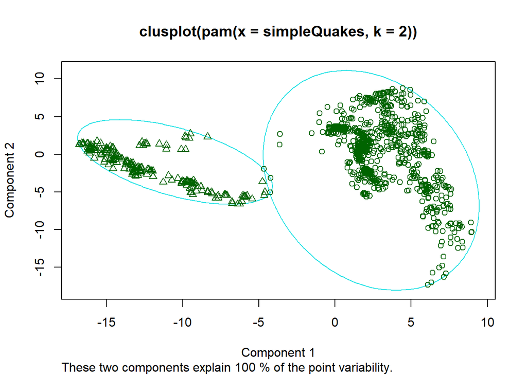

```r
# mypam$clustering # which points belong to which medoid
# same as... pam(simpleQuakes, 4, cluster.only = TRUE)


# plotting PAM
#plot(mypam)
#plot(mypam, ask = TRUE) # menu for plots

#map("worldHires","Fiji", xlim=c(160,190), ylim =c(-40,-15))
plot(mypam, which.plots = 1)
```

## *clara* : Clustering Large Applications

Clara is identical to pam() except subsamples the data before determining medoids.

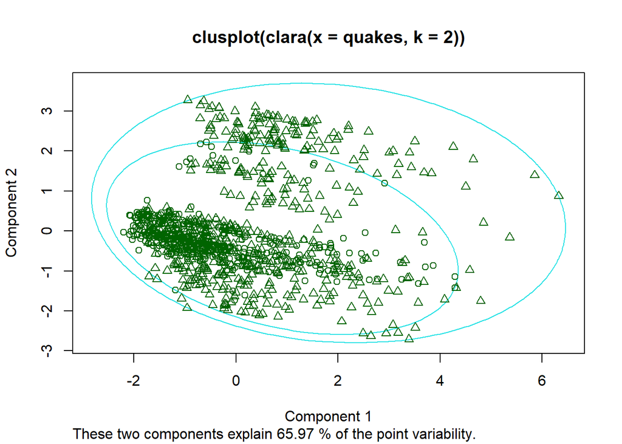

```r
myclara <- clara(quakes,2)
plot(myclara, which.plots = 1) #graph
```

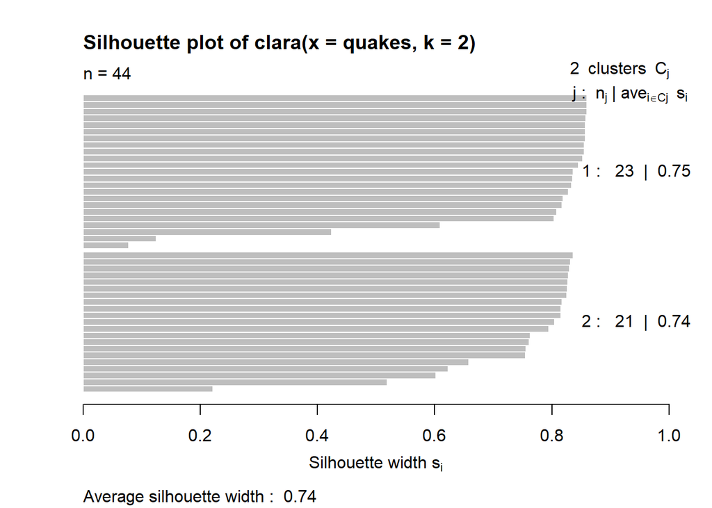

```r
plot(myclara, which.plots = 2) #silhoutte
```